# Simulating Radiological Dating

August 31 2015

### Background

After class on Monday, a student questioned me closely about the fundamentals of how radioactive decay occurs; in particular, how we can work from the idea that a particular radioactive element has a particular half-life.

My answer was that these values are ones that have been determined empirically by nuclear physicists, and that all of the accumulated evidence supports the hypothesis that half-lives are constant. But as I reflected on the conversation, I thought the following might be useful in thinking through the basic concept of a half-life

### Our Thought Experiment

Imagine we start with 100 objects, and during a certain time period, half of them decay. Intuition tells us that we would have 50 left, right? We’ll let’s let the computer do that - essentially flip a coin, with thout come being that coins that come up heads (a 1 in binary notaton) survive and those that come up tails (0) decay. Let’s see what we get:

```
## [1] 47
```

OK. Pretty close. But now, returning to our model, we’re left with 47 undecayed atoms, and **during the next time period, half of them decay**. What happens then?

Well, we can repeat our experiment, only now starting with 47 atoms:

```
## [1] 24
```

```
## [1] 100  47  24   8   6   4
```

And we can make a plot of these data, comparing our observations (shown as black circles) with what we would expect (the red line)

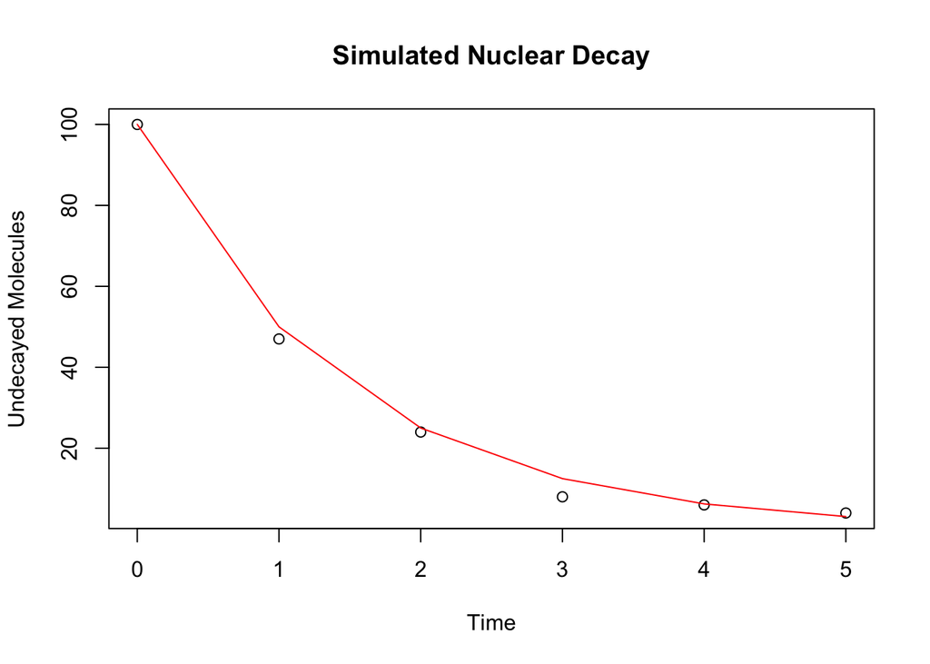

And we see a pretty good fit. But now let’s do somewthing else. Instead of plotting the actual value of the number of undecayed atoms, let’s plot the natural logarithm of them

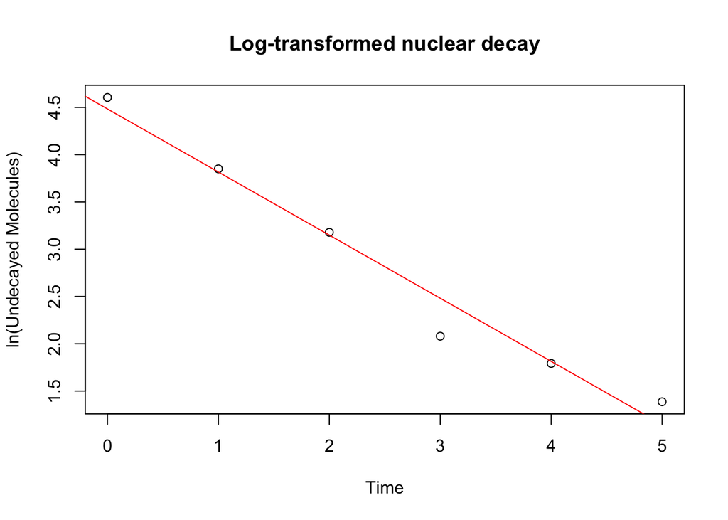

So we get and excellent linear fit. And a couple of important points emerge.

1. The y intercept of the line is in fact the number of molecules at time zero
2. The slope of the line is related to the rate at which the molecules decay (in our case 50% per time period)
3. Therefore, if we had, say the last three samples, we could determine the slope and extrapolate back to time zero, the time at which the mineral was created.

But wait. How do we know how many molecules were there at time zero? This is where isochrons come in. The basic principle is as follows:

1. If we take multiple samples of a rock, the number of radioactive atoms will vary. Let’s suppose we have four samples from a rock had, at the time of crystallization, the following numbers of radioactive atoms:

```
## [1] 2947 4148 7904 8841
```

2. Now they decay. Let’s imagine they all go through 8 half lives. What would we see? In what follows, the columns (X1 through X4) refer to the four samples and the rows (1-8) for time, expressed in half-lives

```
##     X1   X2   X3   X4
## 1 2947 4148 7904 8841
## 2 1461 2050 3885 4329
## 3  730 1030 1941 2168
## 4  364  505  955 1086
## 5  171  227  481  544
## 6   82  117  230  262
## 7   40   52  111  134
## 8   19   24   46   75
```

3. Now, let’s look at what we have at time 8, which corresponds to the time we collected and analyzed the rock. in each of the four samples, there are some decayed atoms and some undecayed: ``

```
##   decayed undecayed
## 1    2928        19
## 2    4124        24
## 3    7858        46
## 4    8766        75
```

4. We can then plot those, along with a best-fit line for the data as follows:

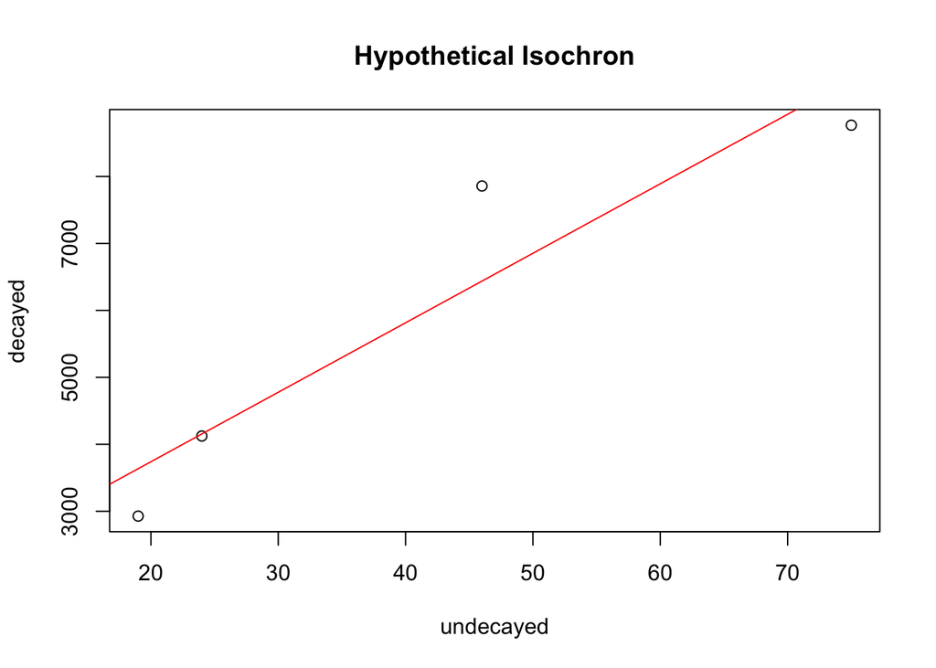

### Conclusion

Finally, look back at our hypothetical isochron. In truth, it is not all that great a fit to a linear relationship. Why not? To answer that, all we need to do is to look at the magnitudes of the numbers of decayed and undecayed atoms. After eight half lives, most of the starting molecules have decayed, so that sampling error alone will generate random variation among the samples.